# Ensambles

Técnicas de Aprendizaje de Máquina

Oscar Bustos

# Introducción

## Tarea: Lecturas

**Actividades a desarrollar:**

1. **(Obligatorio)** Leer el **Capítulo 7** de *Hands-On Machine Learning* (Géron).
2. **(Opcional)** Leer el **Capítulo 8** de *Introduction to Statistical Learning* (James et al.).

## Tarea: NotebookLM

**Actividades complementarias:**

- Explorar el [Cuaderno de Google NotebookLM](https://notebook.google.com/notebook/037da261-6750-4b22-83a2-4d086cc971f7):
  - Revisar la infografía.
  - Realizar los quices incluidos.
  - Escuchar el podcast.

# Acto 1: El Árbol ya no es suficiente

## Árboles dividen el espacio no lineal

**Ventajas del particionamiento:**

- **No lineal:** Separa patrones complejos mediante hiperrectángulos.
- **Interpretable:** Reglas *If-Then* intuitivas y auditables.
- **Sin preprocesamiento:** No requiere escalado de variables.

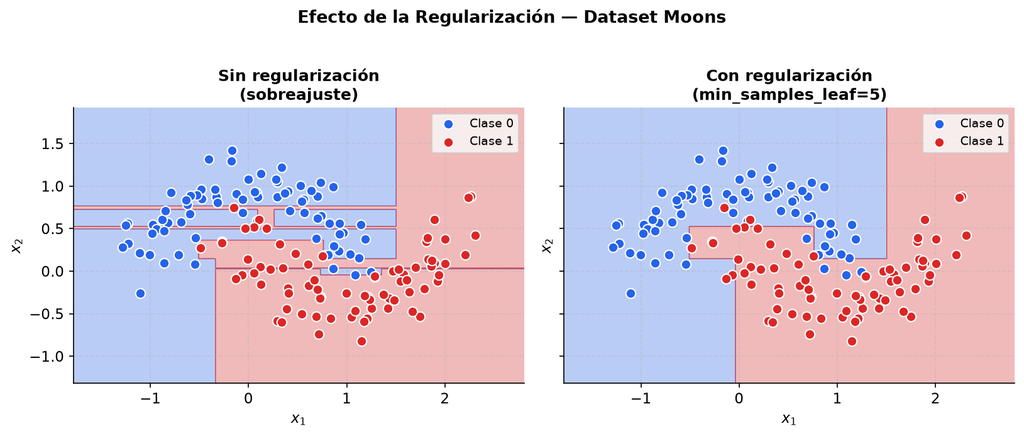

Partición ortogonal del espacio. Tomado de: (Géron 2022)

## CART sufre de alta inestabilidad

**El dilema de la alta varianza:**

- **Algoritmo voraz (*greedy*):** Optimiza divisiones de forma puramente local.
- **Efecto dominó:** Un cambio leve en datos altera la raíz y todo el árbol.

**Problema clave**

Un árbol individual tiene alta varianza y es propenso al sobreajuste.

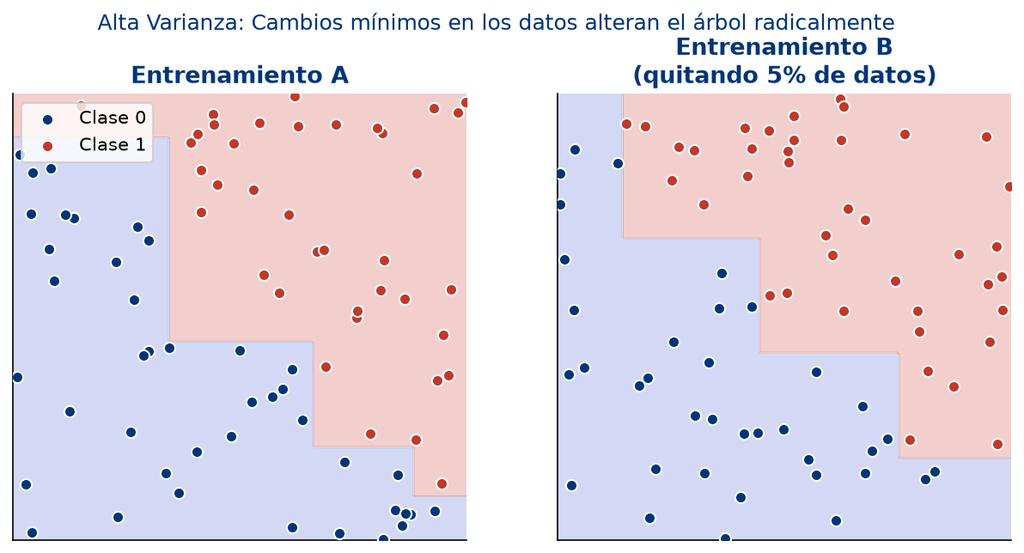

Pequeños cambios en datos generan árboles muy diferentes

## Sabiduría Colectiva en Diagnóstico Médico

¿Cómo toma una decisión crítica un hospital cuando los médicos no se ponen de acuerdo?

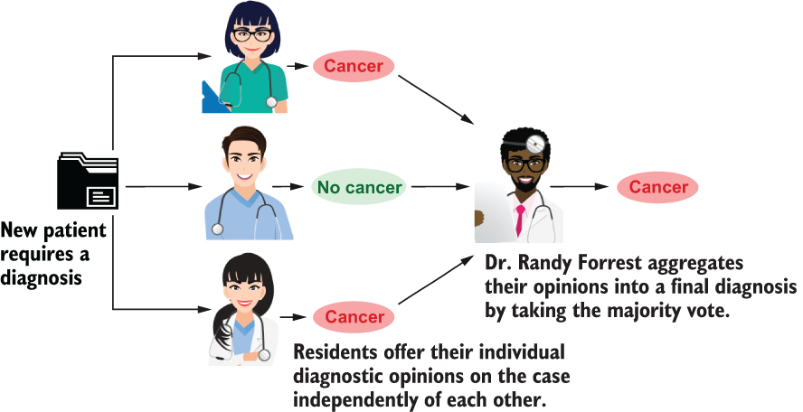

Tomado de: (Kunapuli 2023)

## La IA aplica el mismo principio

En lugar de consultar a un médico más, consultamos a múltiples modelos de ML:

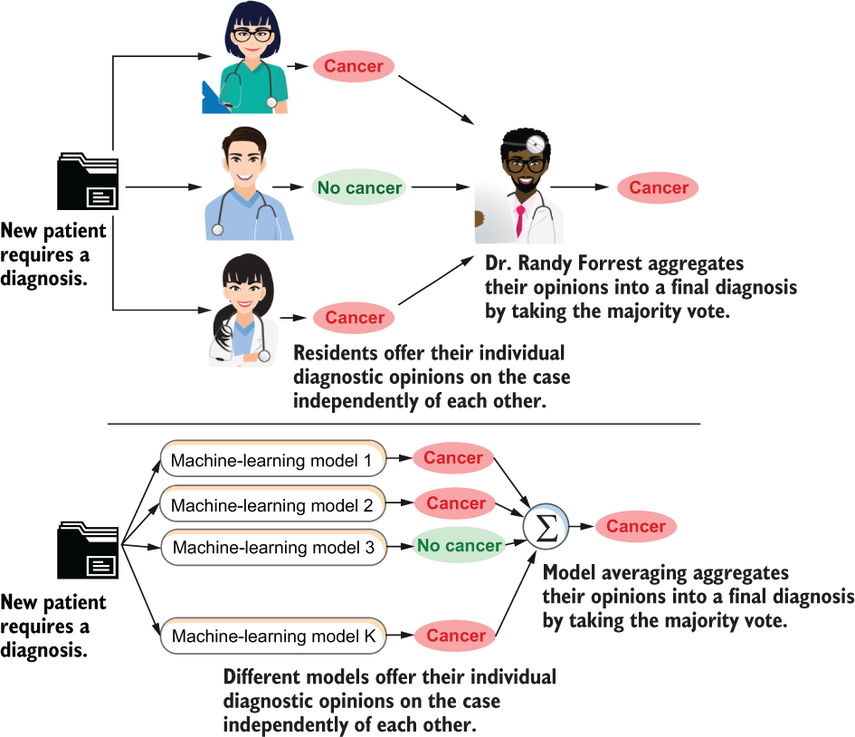

Tomado de: (Kunapuli 2023)

## Evidencia Empírica: los Ensambles Dominan

¿Qué familia de algoritmos lidera el rendimiento en problemas reales? (Olson et al. 2018)

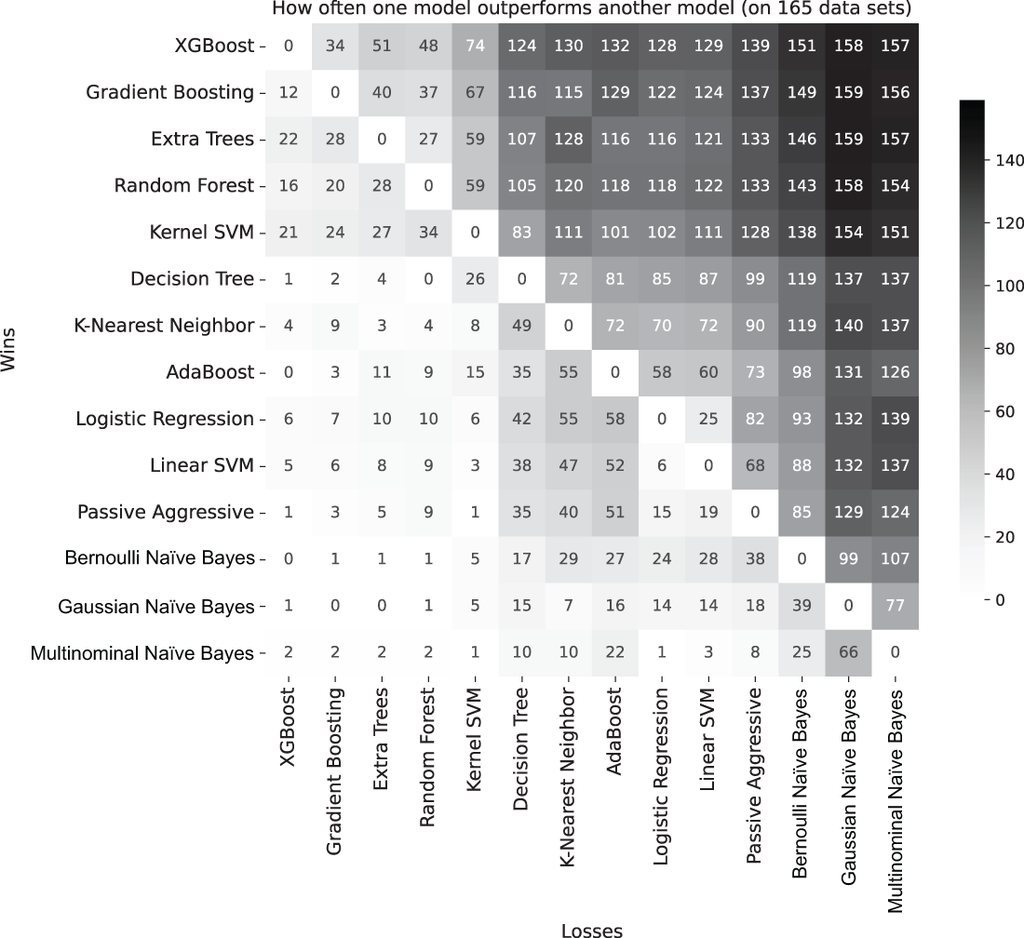

Tomado de: (Olson et al. 2018)

## Tres Familias de Ensambles

**1. Homogéneos**

- Mismo algoritmo, datos diferentes (Bootstrapping).
- Promedian para reducir la **varianza**.

→ *Bagging, Random Forest*

**2. Heterogéneos**

- Distintos algoritmos entrenados en paralelo.
- Combinan predicciones complementarias.

→ *Voting, Stacking*

**3. Secuenciales**

- Modelos en cascada (cada uno corrige al anterior).
- Reducen el **sesgo** progresivamente.

→ *AdaBoost, GBT, XGBoost*

## Bibliografía del Módulo

[figure not shown]

Capítulo 8 (James et al. 2023)

[figure not shown]

Capítulo 7 (Géron 2022)

[figure not shown]

Caps. 1, 2, 3, 5 (Kunapuli 2023)

# Acto 2: Bagging — Mucho de lo mismo, promediado

## Arquitectura de Ensamble Homogéneo

Todos los estimadores base pertenecen a la misma familia algorítmica:

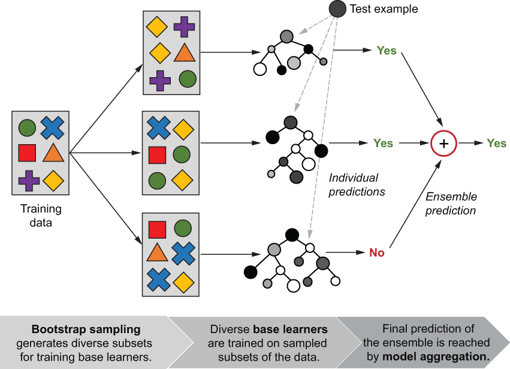

Tomado de: (Kunapuli 2023)

## El Problema: Solo Tenemos Un Dataset

**Pregunta clave**

Si quiero entrenar 200 árboles distintos pero solo tengo **un** dataset de entrenamiento… ¿cómo los hago verdaderamente diferentes entre sí?

**Respuesta:** Bootstrap — muestreo con reemplazo para generar N muestras diversas del mismo dataset original.

## Bootstrap: Diversidad desde un Solo Dataset

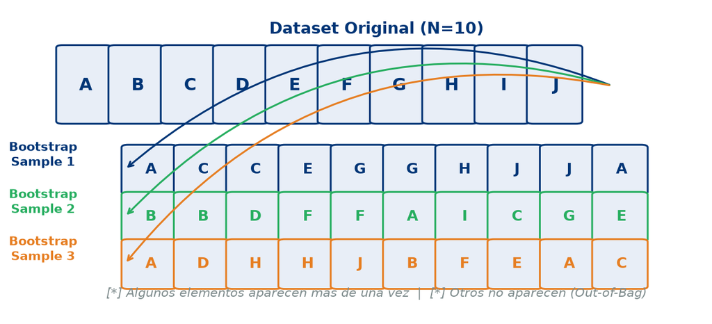

Cada muestra bootstrap puede repetir instancias y omitir otras — generando estimadores genuinamente distintos

## Bagging Reduce Varianza al Promediar

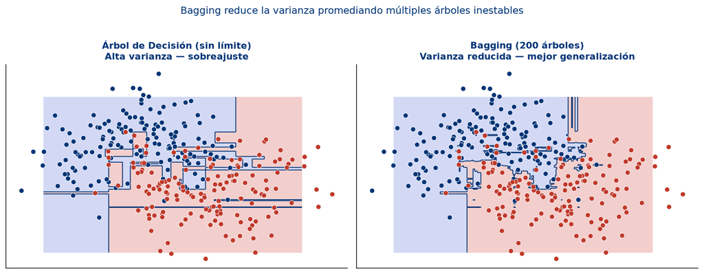

Un árbol profundo sobreajusta (izq.). Promediar 200 árboles suaviza la frontera de decisión (der.)

## OOB: Validación Gratuita con Bootstrap

En cada árbol, las muestras **no seleccionadas** actúan como validation set automático:

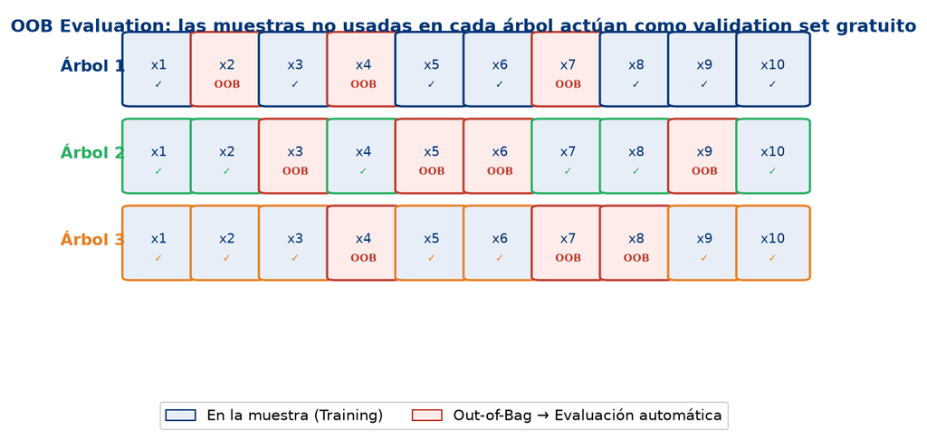

`oob_score_` en sklearn: estimación del error de generalización sin necesitar un test set separado

## Implementación Manual de Bagging

```python
import numpy as np
from sklearn.tree import DecisionTreeClassifier
from scipy.stats import mode

rng = np.random.RandomState(seed=4190)

def bagging_fit(X, y, n_estimators=200, max_depth=5, max_samples=200):
    estimators = [DecisionTreeClassifier(max_depth=max_depth) for _ in range(n_estimators)]
    for tree in estimators:
        bag = rng.choice(len(y), max_samples, replace=True)   # Bootstrap
        tree.fit(X[bag], y[bag])
    return estimators

def bagging_predict(X, estimators):
    all_preds = np.array([tree.predict(X) for tree in estimators])
    ypred, _ = mode(all_preds, axis=0, keepdims=False)
    return np.squeeze(ypred)
```

## BaggingClassifier en Scikit-Learn

```python
from sklearn.tree import DecisionTreeClassifier
from sklearn.ensemble import BaggingClassifier

bag_ens = BaggingClassifier(
    estimator=DecisionTreeClassifier(max_depth=10),
    n_estimators=500,
    max_samples=200,
    oob_score=True,       # Habilita evaluación OOB automática
    n_jobs=-1,            # Paraleliza en todos los CPUs
    random_state=42
)
bag_ens.fit(X_train, y_train)

print(f"OOB Score: {bag_ens.oob_score_:.4f}")  # Sin usar datos de test
print(f"Test Score: {bag_ens.score(X_test, y_test):.4f}")
```

## El Nuevo Problema: Árboles Correlacionados

**Problema de correlacion**

**Solución:** En cada división de cada árbol, considerar solo un **subconjunto aleatorio de features**.

## Random Forest: Cortar la Correlación

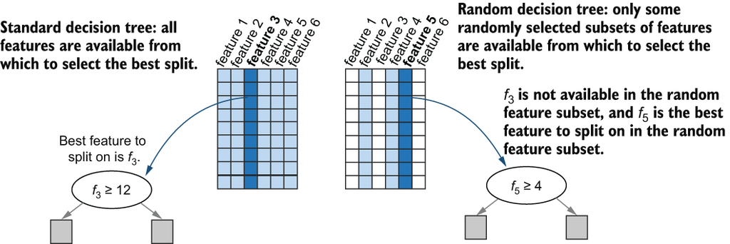

Selección aleatoria de características en cada nodo → decorrelación entre árboles (Kunapuli 2023)

## RandomForestClassifier en Scikit-Learn

```python
from sklearn.ensemble import RandomForestClassifier

rf = RandomForestClassifier(
    n_estimators=500,
    max_features="sqrt",    # sqrt(p) features por division — clave de RF
    max_depth=10,
    oob_score=True,
    n_jobs=-1,
    random_state=42
)
rf.fit(X_train, y_train)

print(f"OOB Score: {rf.oob_score_:.4f}")

# Importancia de variables (Gini Importance)
for feat, imp in sorted(zip(feature_names, rf.feature_importances_),
                         key=lambda x: -x[1])[:5]:
    print(f"  {feat}: {imp:.3f}")
```

## Fronteras de Decisión en Random Forest

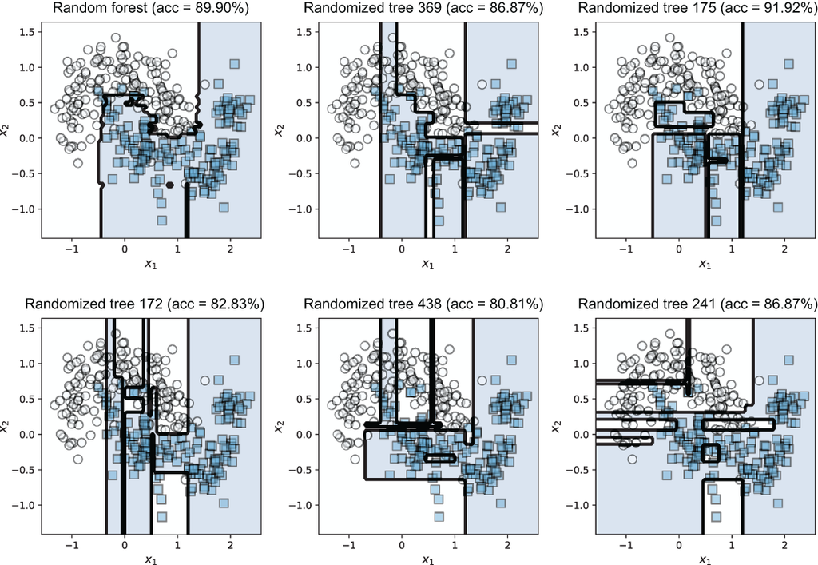

Tomado de: (Kunapuli 2023)

## Extra: Extra-Trees, Aún Más Aleatorio

**Random Forest:** - Evalúa el umbral óptimo para cada feature aleatoria. - Más preciso en cada corte, pero más lento.

**Extra-Trees (`ExtraTreesClassifier`):** - El umbral de corte también es **aleatorio**. - Mucho más rápido de entrenar. - Puede ser más regularizado (menor varianza).

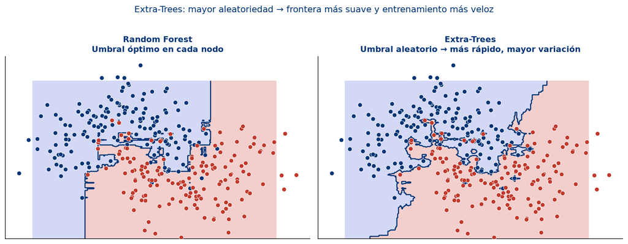

Fronteras similares, entrenamiento más veloz

## Importancia de Variables en Random Forest

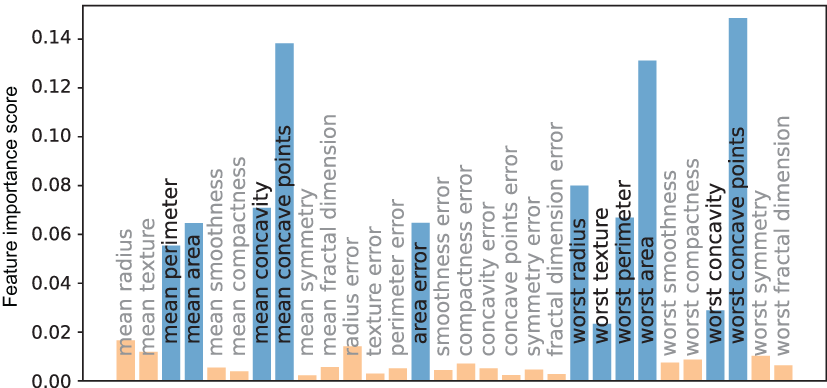

`feature_importances_` — qué variables son más informativas para las divisiones (Kunapuli 2023)

## Hiperparámetros Clave en RF y Bagging

| Hiperparámetro | Descripción | Valor típico |
| --- | --- | --- |
| `n_estimators` | Número de árboles | 100–500 |
| `max_features` | Features por división | `"sqrt"` (RF) / `1.0` (Bagging) |
| `max_depth` | Profundidad máxima | `None` o 10–20 |
| `min_samples_leaf` | Muestras mínimas en hoja | 1–5 |
| `oob_score` | Activa evaluación OOB | `True` |
| `n_jobs` | Paralelismo en CPU | `-1` |

# Acto 3: Voting y Stacking — Lo mejor de mundos distintos

## El Problema: Mismo Tipo de Modelo, Mismos Puntos Ciegos

**Limitacion de Bagging**

Bagging reduce la varianza de **un solo tipo** de modelo. Pero si un SVM, un árbol y una regresión logística cometen errores **en puntos distintos**, ¿podríamos combinarlos para que se complementen?

**Respuesta:** Combinar modelos de distinta naturaleza en un ensamble heterogéneo.

## Arquitectura de Ensamble Heterogéneo

Clasificadores de distinta naturaleza algorítmica trabajando en paralelo:

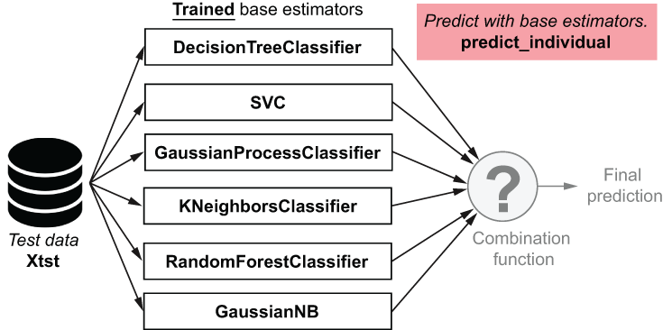

Tomado de: (Kunapuli 2023)

## Hard Voting vs Soft Voting

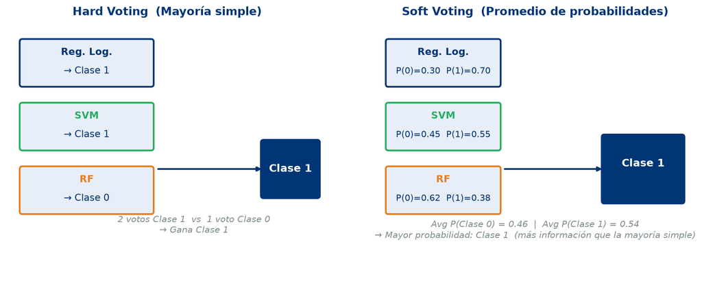

Soft Voting usa `predict_proba` — aprovecha más información que la votación por mayoría

## VotingClassifier en Scikit-Learn

```python
from sklearn.linear_model import LogisticRegression
from sklearn.svm import SVC
from sklearn.ensemble import RandomForestClassifier, VotingClassifier

log_clf = LogisticRegression(random_state=42)
svm_clf = SVC(probability=True, random_state=42)   # probability=True para soft voting
rf_clf  = RandomForestClassifier(n_estimators=100, random_state=42)

voting = VotingClassifier(
    estimators=[("lr", log_clf), ("svm", svm_clf), ("rf", rf_clf)],
    voting="soft"   # "hard" para mayoria simple, "soft" para promedio de probabilidades
)
voting.fit(X_train, y_train)
print(f"Voting Accuracy: {voting.score(X_test, y_test):.4f}")
```

## Métodos de Votación: Diagramas

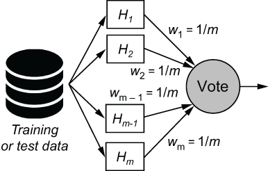

Votación Mayoritaria (Hard) (Kunapuli 2023)

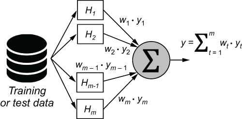

Votación Ponderada (Soft) (Kunapuli 2023)

## El Siguiente Problema: ¿Cómo Combinarlos Óptimamente?

**Pregunta**

Votar por mayoría o promediar trata a todos los modelos por igual. Pero el SVM puede ser mejor en ciertas regiones, y el RF mejor en otras. ¿Podría **aprenderse** la mejor forma de combinarlos?

**Respuesta:** Stacking — un meta-modelo aprende a combinar las predicciones.

## Stacking: El Meta-Modelo Aprende a Combinar

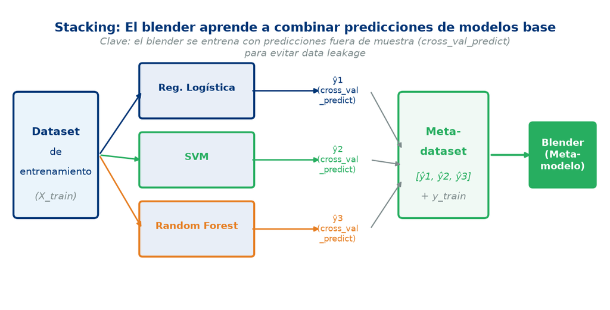

El blender se entrena con predicciones fuera de muestra (`cross_val_predict`) para evitar data leakage

## StackingClassifier en Scikit-Learn

```python
from sklearn.ensemble import StackingClassifier
from sklearn.linear_model import LogisticRegression

base_learners = [
    ("rf",  RandomForestClassifier(n_estimators=100, random_state=42)),
    ("svm", SVC(probability=True, kernel="rbf", random_state=42)),
]

stacking = StackingClassifier(
    estimators=base_learners,
    final_estimator=LogisticRegression(),  # el blender (meta-modelo)
    cv=5,                                  # cross_val_predict con 5 folds
    passthrough=False
)
stacking.fit(X_train, y_train)
print(f"Stacking Accuracy: {stacking.score(X_test, y_test):.4f}")
```

`cv=5` garantiza que el blender nunca entrena con predicciones que sus modelos base ya vieron.

## Stacking: Arquitectura Visual

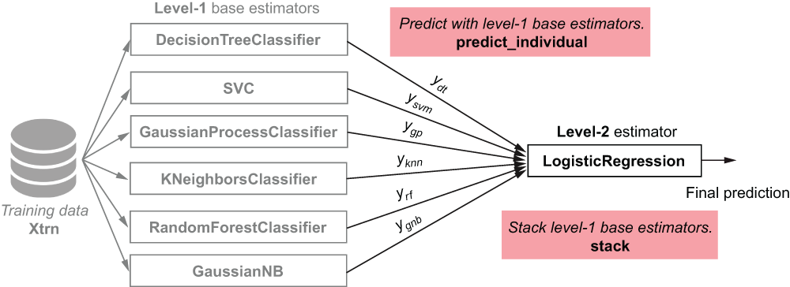

Tomado de: (Kunapuli 2023)

# Acto 4: Boosting — Aprender de los propios errores

## El Problema con el Promedio

**Limitacion del Promedio**

Bagging **promedia** predicciones: trata igual a todas las muestras, fáciles y difíciles. ¿Y si en vez de eso construimos cada nuevo modelo **específicamente para corregir** los errores del modelo anterior?

Esto es **Boosting**: aprendizaje secuencial y adaptativo.

## Arquitectura de Gradient Boosting

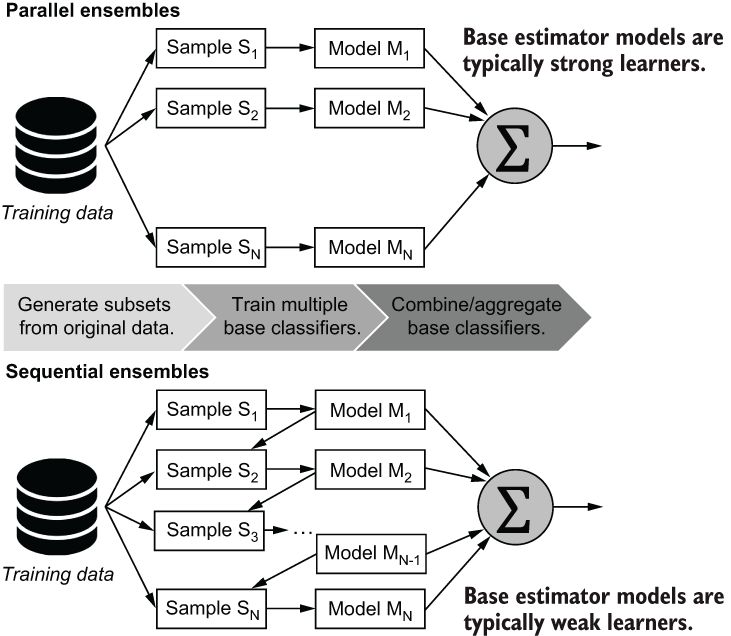

Tomado de: (Kunapuli 2023)

## AdaBoost: Ponderar las Instancias Difíciles

**Mecanismo:**

1. Entrena un clasificador débil (decision stump).
2. Aumenta el peso de las instancias **mal clasificadas** (★).
3. El siguiente clasificador se enfoca en ellas.

**Pesos del predictor:**
$$\alpha_j = \eta \cdot \log\frac{1 - r_j}{r_j}$$

donde $r_j$ es la tasa de error ponderada.

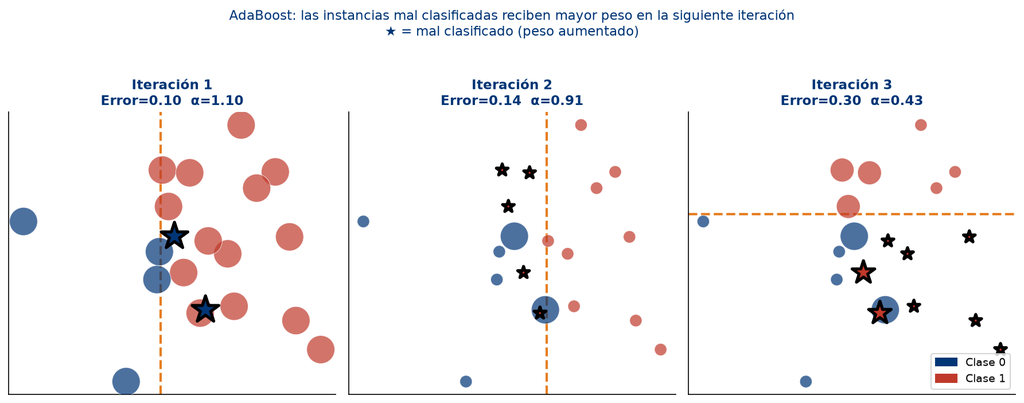

Las ★ son instancias mal clasificadas — su peso crece en cada iteración

## AdaBoostClassifier en Scikit-Learn

```python
from sklearn.ensemble import AdaBoostClassifier
from sklearn.tree import DecisionTreeClassifier

ada = AdaBoostClassifier(
    estimator=DecisionTreeClassifier(max_depth=1),   # decision stumps
    n_estimators=200,
    learning_rate=0.5,      # reduce la contribucion de cada clasificador
    algorithm="SAMME",      # SAMME.R usa predict_proba (mas eficiente)
    random_state=42
)
ada.fit(X_train, y_train)
print(f"AdaBoost Accuracy: {ada.score(X_test, y_test):.4f}")
```

## Entrenamiento Secuencial en AdaBoost

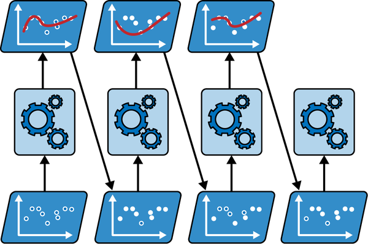

Tomado de: (Géron 2022)

**GBT difiere de AdaBoost:**

- No pondera instancias.
- Cada árbol modela directamente los **residuos** ($y - \hat{y}$) del modelo anterior.
- Equivale a un gradiente descendente en el espacio de funciones.

[figure not shown]

Tomado de: (Kunapuli 2023)

Cada nuevo árbol modela los pseudo-residuos acumulados:

$$\hat{y}^{(m)} = \hat{y}^{(m-1)} + \eta \cdot h_m(x)$$

donde $\eta$ es el `learning_rate` (*shrinkage*).

[figure not shown]

Tomado de: (Kunapuli 2023)

## GBT Paso 3: Convergencia del Ensamble

- El ensamble final captura patrones no lineales complejos.
- Demasiados árboles → sobreajuste en el conjunto de entrenamiento.

**Pregunta:** ¿Cómo sabemos cuántos árboles son suficientes?

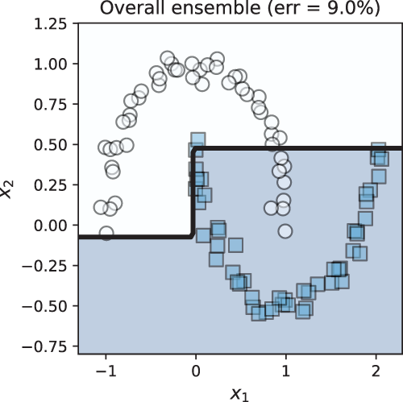

Tomado de: (Kunapuli 2023)

## Early Stopping: Detener en el Momento Óptimo

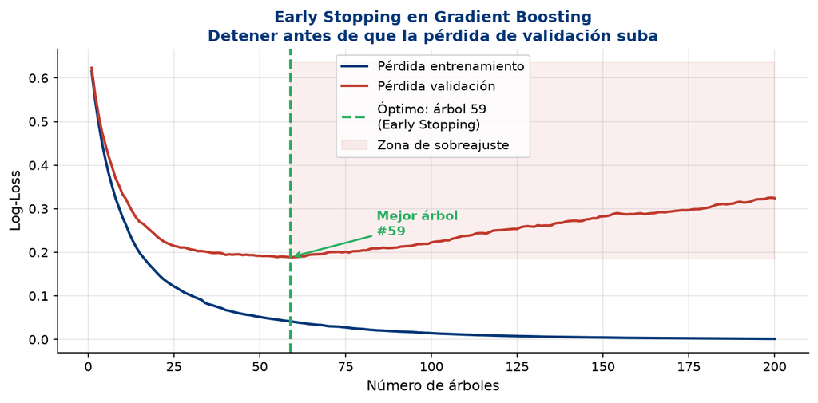

La pérdida de validación marca el número óptimo de árboles — agregar más solo sobreajusta

## GradientBoostingClassifier en Scikit-Learn

```python
from sklearn.ensemble import GradientBoostingClassifier

gbt = GradientBoostingClassifier(
    n_estimators=500,
    learning_rate=0.05,          # shrinkage: menor = necesita mas arboles pero generaliza mejor
    max_depth=3,                 # arboles poco profundos son la norma en GBT
    subsample=0.8,               # Stochastic GB: usar 80% de datos por arbol
    n_iter_no_change=20,         # Early stopping: detener si no mejora en 20 iteraciones
    validation_fraction=0.1,     # 10% para evaluacion de early stopping
    tol=1e-4,
    random_state=42
)
gbt.fit(X_train, y_train)
print(f"GBT Accuracy: {gbt.score(X_test, y_test):.4f}")
print(f"Arboles utilizados: {gbt.n_estimators_}")
```

## HistGradientBoosting: GBT Industrial

**El problema del GBT clásico:**

- Evalúa $O(N \times M \times \log M)$ umbrales.
- Lento con datasets grandes.

**HistGBT discretiza features en bins:**

- Solo evalúa $O(K \times M)$ umbrales.
- $K$ bins (máx. 255 por defecto).
- Soporta **valores nulos** nativamente.
- Soporta **variables categóricas** sin One-Hot.

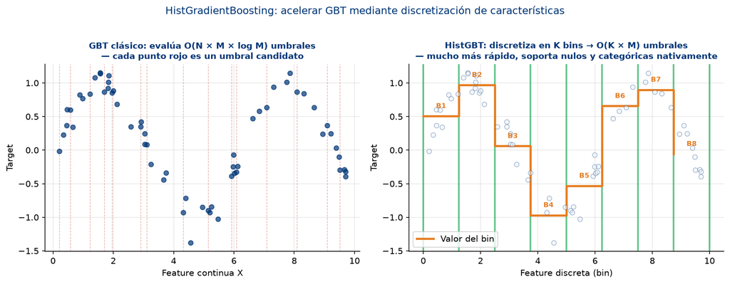

Discretización en histogramas — misma idea, fracción del costo computacional

## HistGradientBoosting en Scikit-Learn

```python
from sklearn.ensemble import HistGradientBoostingClassifier
import pandas as pd

# Puede manejar directamente DataFrames con nulos y categoricas
gbt_hist = HistGradientBoostingClassifier(
    max_iter=500,
    learning_rate=0.05,
    max_depth=6,
    max_bins=255,                             # bins de discretizacion
    categorical_features="from_dtype",        # detecta categoricas automaticamente
    early_stopping=True,
    validation_fraction=0.1,
    n_iter_no_change=20,
    random_state=42
)
gbt_hist.fit(X_train, y_train)
```

## Hiperparámetros Clave en GBT

- `n_estimators` / `max_iter`: Número total de árboles secuenciales.
- `learning_rate`: Peso de cada árbol (*shrinkage*). Menor → más árboles necesarios pero mejor generalización.
- `max_depth`: Profundidad máxima (2–6 es lo habitual en GBT).
- `subsample`: Fracción de datos por árbol — *Stochastic Boosting*.
- `n_iter_no_change` + `validation_fraction`: Early Stopping automático.

# Acto 5: El Ecosistema — ¿Cuál Usar?

## Guía de Selección de Algoritmos

¿Cómo seleccionar el ensamble adecuado para tu problema?

[figure not shown]

Tomado de: (Géron 2022)

## Random Forest vs Gradient Boosted Trees

| **Característica** | **Random Forest** | **Gradient Boosted Trees** |
| --- | --- | --- |
| **Enfoque** | Bagging (Paralelo) | Boosting (Secuencial) |
| **Paralelización** | Total: cada árbol es independiente | Parcial: paraleliza dentro de cada árbol |
| **Rendimiento** | Alta precisión y estabilidad | Máxima precisión (SOTA en datos tabulares) |
| **Sobreajuste** | Bajo riesgo — asintótico al sumar árboles | Alto riesgo si no se usa early stopping |
| **Sensibilidad** | Robusto a hiperparámetros por defecto | Muy sensible a `learning_rate` y `max_depth` |
| **Nulos / Categóricas** | Requiere imputación / One-Hot previo | HistGBT soporta ambos nativamente |
| **Importancia de vars** | Gini / Permutación | Ganancia / Cobertura / SHAP |

## Comparativa de Librerías en Python

| **Modelo** | **Librería** | **Estrategia** | **Categóricas** | **Nulos** | **Velocidad** |
| --- | --- | --- | --- | --- | --- |
| **Random Forest** | `scikit-learn` | Bagging | Requiere codificación | No nativo | Paralelo, más RAM |
| **Gradient Boosting** | `scikit-learn` | Boosting secuencial | Requiere codificación | Solo HistGBT | Moderado |
| **XGBoost** | `xgboost` | Level-wise Boosting | Soporte experimental | Nativo (dirección óptima) | Muy rápido (C++ / GPU) |
| **LightGBM** | `lightgbm` | Leaf-wise Boosting | Nativo y eficiente | Nativo | Extremadamente rápido |
| **CatBoost** | `catboost` | Oblivious Trees | Nativo especializado | Nativo | Inferencia ultra rápida |

## Código: XGBoost

```python
import xgboost as xgb

xgb_model = xgb.XGBClassifier(
    n_estimators=500,
    max_depth=5,
    learning_rate=0.05,
    subsample=0.8,
    colsample_bytree=0.8,
    early_stopping_rounds=20,
    eval_metric="logloss",
    random_state=42
)
xgb_model.fit(X_train, y_train,
              eval_set=[(X_val, y_val)],
              verbose=False)
print(f"XGBoost Accuracy: {xgb_model.score(X_test, y_test):.4f}")
```

## Código: LightGBM

```python
import lightgbm as lgb

lgb_model = lgb.LGBMClassifier(
    n_estimators=500,
    num_leaves=63,          # leaf-wise: controla la complejidad
    learning_rate=0.05,
    subsample=0.8,
    colsample_bytree=0.8,
    min_child_samples=20,
    random_state=42
)
lgb_model.fit(
    X_train, y_train,
    eval_set=[(X_val, y_val)],
    callbacks=[lgb.early_stopping(20), lgb.log_evaluation(0)]
)
print(f"LightGBM Accuracy: {lgb_model.score(X_test, y_test):.4f}")
```

## Código: Random Forest en Scikit-Learn

```python
from sklearn.ensemble import RandomForestClassifier
from sklearn.model_selection import train_test_split
from sklearn.metrics import accuracy_score

X_train, X_test, y_train, y_test = train_test_split(X, y, test_size=0.2, random_state=42)

rf = RandomForestClassifier(n_estimators=200, max_features="sqrt",
                            oob_score=True, n_jobs=-1, random_state=42)
rf.fit(X_train, y_train)

print(f"OOB Score : {rf.oob_score_:.4f}")
print(f"Test Score: {accuracy_score(y_test, rf.predict(X_test)):.4f}")
```

## Referencias

Géron, Aurélien. 2022. *Hands-on Machine Learning with Scikit-Learn, Keras, and TensorFlow: Concepts, Tools, and Techniques to Build Intelligent Systems*. 3rd ed. O’Reilly Media, Inc.

James, Gareth, Daniela Witten, Trevor Hastie, Robert Tibshirani, and Jonathan Taylor. 2023. *An Introduction to Statistical Learning: With Applications in Python*. Springer Nature.

Kunapuli, Gautam. 2023. *Ensemble Methods for Machine Learning*. Simon; Schuster.

Olson, Randal S, William La Cava, Zairah Mustahsan, Akshay Varik, and Jason H Moore. 2018. “Data-Driven Advice for Applying Machine Learning to Bioinformatics Problems.” *Pacific Symposium on Biocomputing 2018: Proceedings of the Pacific Symposium*, 192–203.